# A Short Genetic Adventure

November 6, 2018

## A genetic algorithm (GA) demo

I'll show you a simple example of a genetic algorithm in action.

The algorithm will be used to solve two reinforcement learning problems: cart-pole and mountain-car.

A genetic algorithm can be used for hyper-parameter grid search too.

## A GA will turn this…

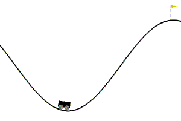

## ..into this fine champion

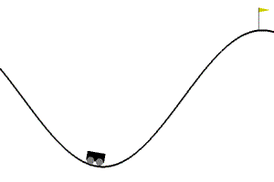

## What are these games?

Cart-pole (v1) is a simple game where you have 500 time steps to keep a pole in a cart from toppling. By moving the cart left or right, you can correct the pole's angle. Drifting off-screen also loses the game. You get 1 reward point for each good timestep.

Mountain-car has you controlling a car that needs to build momentum to get up a steep hill. You receive a -1 penalty for each timestep, so you want to reach the flag as soon as possible.

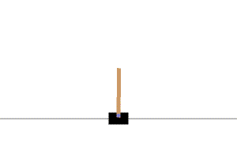

## What this is useful for

Reinforcement learning (RL) problems have an *agent* that performs *actions* in an *environment* in return for a *reward*.

This kind of situation is common when you (human) are learning to play a new game. By trial and error you figure out what's good and bad, the *value function*. You use this to develop a strategy, a *policy*.

It's also the situation we find ourselves in with hyper-parameter tuning.

## Disclaimer: GA is not RL

Genuine RL models craft a value function for the agent.

A GA has no value function and instead searches the parameter space with directed randomness.

1. Initial population
2. Fitness evaluation
3. Selection
4. Mutation
5. Next generation

## GA breakdown (1 of 5)

The GA starts with an initial population. I randomly initialize the parameters (weights) of this initial population.

The randomly generated parameters form the gene pool. Their genetic material will be passed down to subsequent generations.

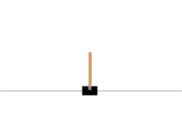

## GA breakdown (2 of 5)

Next come "elitism". The top agents of each round are preserved for the next one. Top performance is chosen by fitness (best reward).

This ensures that the top performers at least stick around for a short while yet.

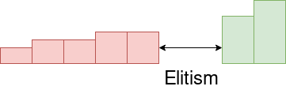

## GA breakdown (3 of 5)

All members of the current generation are eligible to become parents. Their probability of selection is proportional to their fitness.

Since the selection is redone each offspring, a lot of different agents will end up being parents.

Offspring randomly inherit genes (parameters) from their parents. This is how the GA "explores" the parameter space.

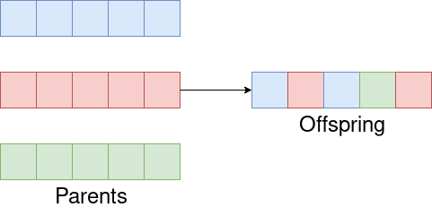

## GA breakdown (4 of 5)

The GA also explores the parameter space with mutations. Genes have a small chance of being modified.

I add small gaussian noise to the parameter. If the mutation is beneficial, it'll be passed down.

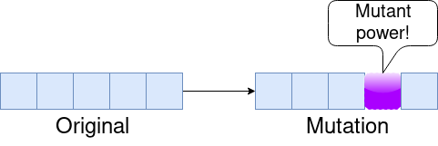

## GA breakdown (5 of 5)

After all of the generation's offspring are created, they're all given a chance to solve the environment.

They'll likely improve the fitness score. If not, continued random breeding might create an improvement eventually.

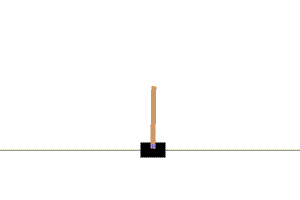

## Playing with the GA was fun

A genetic algorithm is an intuitive solution to reinforcement learning problems.

A GA can be used to optimize something you're not sure how to approach.

Hyper-parameter tuning can be done with a GA, provided you have a quickly-run model. A GA beats grid search.

## Code

You can find this code on my GitHub.

I hope you found this interesting!